# Win Prediction with Random Forest

We will test whether certain stats can help predict whether a team will win. The stats we will be using are the field goal percentage, free throw percentage, three-pointer percentage, assists, and rebounds of each team.

Our target feature will be whether or not the home team wins when these stats are taken into account.

```r
library(C50)
library(caret)
library(gmodels)
library(pROC)
library(randomForest)
```

Now we will load the data, select our features, and normalize the data. We will also set our variables for how much data we will use to train the model, and how much data the model is tested on. We will also factorize whether the home team wins or not.

```r
# the file we will be loading
file <- read.csv("games.csv", header=TRUE, stringsAsFactors = FALSE)

# subset of file with columns that will actually be used, and are complete cases
all_data <- file[complete.cases(file),c("FG_PCT_home","FT_PCT_home","FG3_PCT_home","AST_home",
                                  "REB_home","HOME_TEAM_WINS","PTS_home","PTS_away",
                                  "FG_PCT_away","FT_PCT_away","FG3_PCT_away",
                                  "AST_away",   "REB_away")]

#test all cases complete
sum(complete.cases(all_data))
```

```
## [1] 22945
```

```r
sum(is.na(all_data))
```

```
## [1] 0
```

```r
#factorize home team
all_data$HOME_TEAM_WINS<-factor(all_data$HOME_TEAM_WINS,levels=c(0,1),labels=c("W","L"))

train_num = 17500
test_num = 2500
total=train_num+test_num

#create a normlized version of the data.
n_data <- all_data[ 1:total , c("FG_PCT_home","FT_PCT_home","FG3_PCT_home","AST_home",
                                  "REB_home",
                                  "FG_PCT_away","FT_PCT_away","FG3_PCT_away",
                                  "AST_away",   "REB_away")]

summary(n_data)
```

```
##   FG_PCT_home      FT_PCT_home      FG3_PCT_home       AST_home
##  Min.   :0.2500   Min.   :0.1430   Min.   :0.0000   Min.   : 6.00
##  1st Qu.:0.4210   1st Qu.:0.6960   1st Qu.:0.2800   1st Qu.:19.00
##  Median :0.4590   Median :0.7650   Median :0.3570   Median :22.00
##  Mean   :0.4606   Mean   :0.7582   Mean   :0.3559   Mean   :22.48
##  3rd Qu.:0.5000   3rd Qu.:0.8260   3rd Qu.:0.4290   3rd Qu.:26.00
##  Max.   :0.6750   Max.   :1.0000   Max.   :1.0000   Max.   :47.00
##     REB_home      FG_PCT_away      FT_PCT_away      FG3_PCT_away
##  Min.   :15.00   Min.   :0.2440   Min.   :0.1430   Min.   :0.0000
##  1st Qu.:38.00   1st Qu.:0.4110   1st Qu.:0.6920   1st Qu.:0.2730
##  Median :43.00   Median :0.4470   Median :0.7620   Median :0.3500
##  Mean   :43.02   Mean   :0.4486   Mean   :0.7569   Mean   :0.3493
##  3rd Qu.:47.00   3rd Qu.:0.4860   3rd Qu.:0.8280   3rd Qu.:0.4220
##  Max.   :72.00   Max.   :0.6740   Max.   :1.0000   Max.   :1.0000
##     AST_away        REB_away
##  Min.   : 4.00   Min.   :19.00
##  1st Qu.:18.00   1st Qu.:37.00
##  Median :21.00   Median :41.00
##  Mean   :21.03   Mean   :41.65
##  3rd Qu.:24.00   3rd Qu.:46.00
##  Max.   :46.00   Max.   :71.00
```

```r
normalize <- function(x) {
    return ((x - min(x,na.rm = TRUE)) /  (max(x,na.rm = TRUE) - min(x,na.rm = TRUE)))
}

n_data <- as.data.frame(lapply(n_data, normalize))

summary(n_data)
```

```
##   FG_PCT_home      FT_PCT_home      FG3_PCT_home       AST_home
##  Min.   :0.0000   Min.   :0.0000   Min.   :0.0000   Min.   :0.0000
##  1st Qu.:0.4024   1st Qu.:0.6453   1st Qu.:0.2800   1st Qu.:0.3171
##  Median :0.4918   Median :0.7258   Median :0.3570   Median :0.3902
##  Mean   :0.4955   Mean   :0.7179   Mean   :0.3559   Mean   :0.4019
##  3rd Qu.:0.5882   3rd Qu.:0.7970   3rd Qu.:0.4290   3rd Qu.:0.4878
##  Max.   :1.0000   Max.   :1.0000   Max.   :1.0000   Max.   :1.0000
##     REB_home       FG_PCT_away      FT_PCT_away      FG3_PCT_away
##  Min.   :0.0000   Min.   :0.0000   Min.   :0.0000   Min.   :0.0000
##  1st Qu.:0.4035   1st Qu.:0.3884   1st Qu.:0.6406   1st Qu.:0.2730
##  Median :0.4912   Median :0.4721   Median :0.7223   Median :0.3500
##  Mean   :0.4915   Mean   :0.4758   Mean   :0.7164   Mean   :0.3493
##  3rd Qu.:0.5614   3rd Qu.:0.5628   3rd Qu.:0.7993   3rd Qu.:0.4220
##  Max.   :1.0000   Max.   :1.0000   Max.   :1.0000   Max.   :1.0000
##     AST_away         REB_away
##  Min.   :0.0000   Min.   :0.0000
##  1st Qu.:0.3333   1st Qu.:0.3462
##  Median :0.4048   Median :0.4231
##  Mean   :0.4054   Mean   :0.4356
##  3rd Qu.:0.4762   3rd Qu.:0.5192
##  Max.   :1.0000   Max.   :1.0000
```

Noting from above, we have 22945 complete cases in the data set, and no NA’s, also the data was normalized correctly.

Now we will segment the data between what we will train it on, and what we will test it on.

```r
#segment training data
train_data <- n_data[ (1:train_num) , ]
train_labels <- all_data$HOME_TEAM_WINS[ (1:train_num) ]

#segment testing data
test_data <- n_data[ (train_num + 1) : (train_num+test_num), ]
test_labels <- all_data$HOME_TEAM_WINS[ (train_num+1) : (train_num+test_num)]
```

Now we will now train a subset of the data on the model. And also take a look at the statistics.

```r
model <- randomForest(train_data, train_labels)
pred_labels <- predict(model, test_data)

model
```

```
##
## Call:
##  randomForest(x = train_data, y = train_labels)
##                Type of random forest: classification
##                      Number of trees: 500
## No. of variables tried at each split: 3
##
##         OOB estimate of  error rate: 16.69%
## Confusion matrix:
##      W    L class.error
## W 5386 1629   0.2322167
## L 1291 9194   0.1231283
```

```r
CrossTable(test_labels, pred_labels,
             prop.chisq = FALSE, prop.c = FALSE, prop.r = FALSE,
             dnn = c('actual default', 'predicted default'))
```

```
##
##
##    Cell Contents
## |-------------------------|
## |                       N |
## |         N / Table Total |
## |-------------------------|
##
##
## Total Observations in Table:  2500
##
##
##                | predicted default
## actual default |         W |         L | Row Total |
## ---------------|-----------|-----------|-----------|
##              W |       811 |       240 |      1051 |
##                |     0.324 |     0.096 |           |
## ---------------|-----------|-----------|-----------|
##              L |       166 |      1283 |      1449 |
##                |     0.066 |     0.513 |           |
## ---------------|-----------|-----------|-----------|
##   Column Total |       977 |      1523 |      2500 |
## ---------------|-----------|-----------|-----------|
##
##
```

```r
confusionMatrix(pred_labels,
    test_labels, positive = "W")
```

```
## Confusion Matrix and Statistics
##
##           Reference
## Prediction    W    L
##          W  811  166
##          L  240 1283
##
##                Accuracy : 0.8376
##                  95% CI : (0.8225, 0.8519)
##     No Information Rate : 0.5796
##     P-Value [Acc > NIR] : < 2.2e-16
##
##                   Kappa : 0.6635
##
##  Mcnemar's Test P-Value : 0.0002913
##
##             Sensitivity : 0.7716
##             Specificity : 0.8854
##          Pos Pred Value : 0.8301
##          Neg Pred Value : 0.8424
##              Prevalence : 0.4204
##          Detection Rate : 0.3244
##    Detection Prevalence : 0.3908
##       Balanced Accuracy : 0.8285
##
##        'Positive' Class : W
##
```

From this we can see that the model gave us a pretty good accuracy right away. It correctly identified 84% of the testing samples. It also has a good Kappa value.

We will now try to train the model to try and find an even better model. We will use the ROC curve to pick out the best one.

```r
ctrl <- trainControl(method = "repeatedcv",
                       repeats = 2, number = 10,
                       selectionFunction = "best",
                       savePredictions = TRUE,
                       classProbs = TRUE,
                       summaryFunction = twoClassSummary)

grid_rf <- expand.grid(mtry = c(1, 4, 8, 16))

RNGversion("3.5.2"); set.seed(300)

m_rf <- train(y=train_labels, x = train_data, method = "rf",
                metric = "ROC", trControl = ctrl,
                tuneGrid = grid_rf)
```

Now we will plot an ROC curve. And take a look at the results.

```r
m_rf
```

```
## Random Forest
##
## 17500 samples
##    10 predictor
##     2 classes: 'W', 'L'
##
## No pre-processing
## Resampling: Cross-Validated (10 fold, repeated 2 times)
## Summary of sample sizes: 15751, 15750, 15750, 15749, 15751, 15751, ...
## Resampling results across tuning parameters:
##
##   mtry  ROC        Sens       Spec
##    1    0.9176698  0.7546664  0.8909858
##    4    0.9147588  0.7705608  0.8772515
##    8    0.9122656  0.7716286  0.8763457
##   16    0.9113131  0.7715592  0.8745812
##
## ROC was used to select the optimal model using the largest value.
## The final value used for the model was mtry = 1.
```

```r
m_rf$finalModel
```

```
##
## Call:
##  randomForest(x = x, y = y, mtry = param$mtry)
##                Type of random forest: classification
##                      Number of trees: 500
## No. of variables tried at each split: 1
##
##         OOB estimate of  error rate: 16.22%
## Confusion matrix:
##      W    L class.error
## W 5327 1688   0.2406272
## L 1150 9335   0.1096805
```

```r
roc_rf <- roc(m_rf$pred$obs, m_rf$pred$W)
```

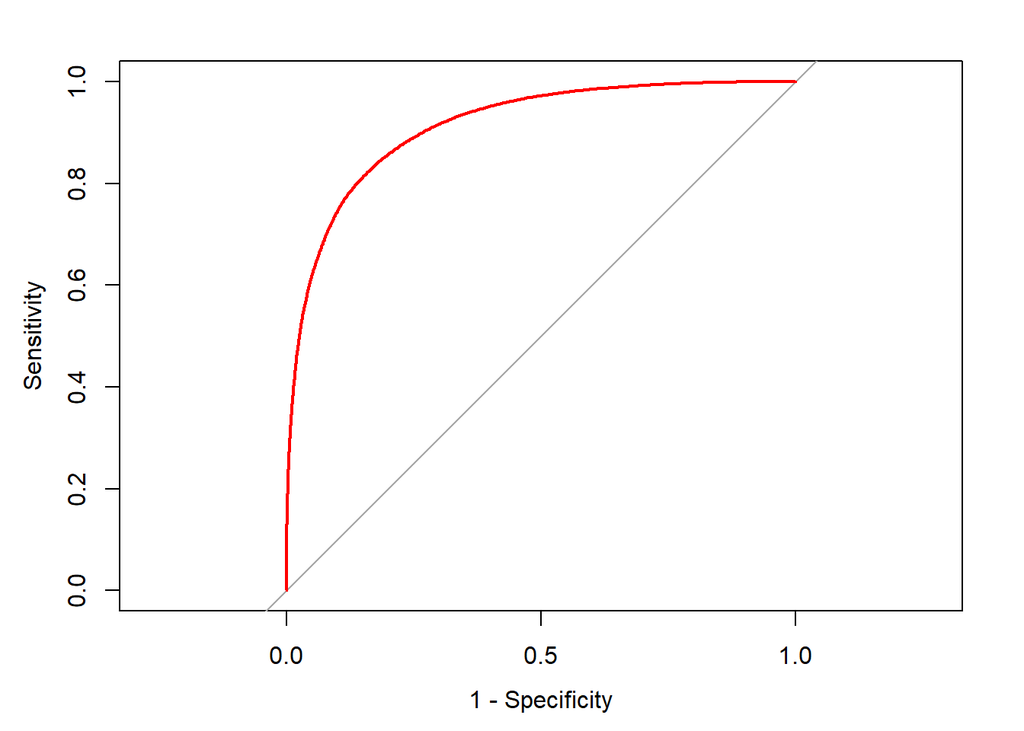

```r
plot(roc_rf, col = "red", legacy.axes = TRUE)
```

Now we will use the model that resulted and see if our results have improved over the original random forest model.

```r
pred_labels <- predict(m_rf,test_data)

table(pred_labels,test_labels)
```

```
##            test_labels
## pred_labels    W    L
##           W  791  155
##           L  260 1294
```

```r
confusionMatrix(pred_labels,
    test_labels, positive = "W")
```

```
## Confusion Matrix and Statistics
##
##           Reference
## Prediction    W    L
##          W  791  155
##          L  260 1294
##
##                Accuracy : 0.834
##                  95% CI : (0.8188, 0.8484)
##     No Information Rate : 0.5796
##     P-Value [Acc > NIR] : < 2.2e-16
##
##                   Kappa : 0.6546
##
##  Mcnemar's Test P-Value : 3.305e-07
##
##             Sensitivity : 0.7526
##             Specificity : 0.8930
##          Pos Pred Value : 0.8362
##          Neg Pred Value : 0.8327
##              Prevalence : 0.4204
##          Detection Rate : 0.3164
##    Detection Prevalence : 0.3784
##       Balanced Accuracy : 0.8228
##
##        'Positive' Class : W
##
```

The result from the trained model is actually slightly less than the first random forest we tried. So we will stay with the original as our model which had an accuracy rate of 84%.

It appears that with the data given, we were able to predict reasonably accurately whether the home team would win a game.